# Open-Ended Registration: Modelling the Development of Preschoolers’ Fairness Judgements

Peidong Mei

15/03/2021

## 1 Study Information

#### 1.1 Title

The Cost of Fairness: Its Dynamic Influence on Developmental Stage, Competition and Relation in British and Chinese Preschoolers’ Resource Allocations.

#### 1.2 Authorship

Peidong Mei & Charlie Lewis <sup>1</sup>

<sup>1</sup> Lancaster University

#### 1.4 License

Not applicable.

#### 1.5 Tags

- Fairness
- Resource Allocation
- Cross-cultural Comparison
- Early Moral Development
- Bayesian Multinomial Modelling
- R package ‘brms’

#### 1.6 Summary

This project was registered after the study had been completed. We want to include a full picture of the complex modelling employed in the study.

This registration involves the dataset description and the analysis process. In the dataset section, we provided detailed definitions of all variables with their specific levels. A descriptive summary of the dataset can also be found. The analysis process includes the R package we used for modelling, prior and baseline information, model construction and selection. Output summaries of all the models that we run were also included.

## 2 Dataset Description

Our independent variables involoved three within subject variables: - **`cost`**(cost vs cost-free) - **`competition`**(competition vs free play) - **`relation`** (friend vs unknown peer)

We also collected three between subject variables: - **`country`**(China vs UK) - **`age group`**(Older vs Younger) - **`gender`**(Female vs Male)

These are all binary and the former level in each bracket was used as the baseline in following models.

The dependent variable is **`allocation`** and has three levels: fair (equal split), unfair but advantageous (the distributor gets more) and unfair but disadvantageous (the distributor gets less).

```r
summary(Subject)
```

```
##     child                age          age_group   country     gender
##  Length:204         Min.   :38.00   Older  : 96   CN:104   Female: 87
##  Class :character   1st Qu.:53.00   Younger:108   UK:100   Male  :117
##  Mode  :character   Median :62.00
##                     Mean   :61.64
##                     3rd Qu.:72.00
##                     Max.   :82.00
```

```r
summary(Response)
```

```
##    fairness    allocation       justification
##  Fair  :1052   Fair :1052   Desire     :457
##  Unfair: 580   UFad : 425   Norm       :932
##                UFdis: 155   Affiliation:135
##                             Conduct    : 52
##                             Uncodable  : 56
```

## 3 Statistical Analysis

#### 3.1 Modelling Process

We used [**`brm()`**](https://cran.r-project.org/web/packages/brms/brms.pdf), which is a Bayesian Regression Modelling approach using the platform *‘Stan’* to explore the predictive effects of all six factors and their possible interactions on children’s allocations.

The *default priors* were used for two reasons: first, model diagnosis indicated that the default priors were vague enough to avoid any substantial effects on the model and allowed the dataset to be converted well; secondly, to the best of our knowledge, there were no solid grounds from previous research on this topic available for us to consider more beneficial priors.

In addition, the response baseline used in the modelling, also known as the referential information to posterior distribution, was the ‘fair’ response from the allocation measurement (i.e. the child and recipeint both get the same amount). The ‘fair’ response was predominant (64.46%), compared to an ‘advantage-self’ response of 26.04% and a ‘disadvantage-self’ response of 9.5%. Taking the majority response as the baseline can favour the stability and accuracy of these models.

```r
######### reparameterize baseline #########
R2long$age_group=relevel(R2long$age_group, ref='Older')
R2long$country=relevel(R2long$country, ref='CN')
R2long$gender=relevel(R2long$gender, ref='Female')
R2long$cost=relevel(R2long$cost, ref='Cost')
R2long$competition=relevel(R2long$competition, ref='Competition')
R2long$relation=relevel(R2long$relation, ref='Friend')
R2long$allocation<-factor(R2long$allocation,
                          levels=c("Fair","UFad","UFdis"))
```

Six models were computed using the bottom-up approach: starting with the simplest (Model 1) with only the main effect of each variable, then the following models added interactions from 2-way (Model 2) up to 6-way (Model 6). All the models included a random intercept of subject to minimize any participant differences and were fitted using four chains, each with 2,000 iterations (1,000 warm up) under the family setting “categorical’.

```r
##################### just 6 main effects
brm2.1 <- brm(allocation~age_group+gender+country+competition+relation+cost
              +(1|id),data=R2long,family=categorical,save_all_pars=T)

##################### add all 6 effects with 2way interactions
brm2.2 <- brm(allocation~(age_group+gender+country+competition+relation+cost)^2
              +(1|id),data=R2long,family=categorical,save_all_pars=T)

##################### add all 6 effects with 3way interactions
brm2.3 <- brm(allocation~(age_group+gender+country+competition+relation+cost)^3
              +(1|id),data=R2long,family=categorical,save_all_pars=T)

##################### add all 6 effects with 4way interactions
brm2.4 <- brm(allocation~(age_group+gender+country+competition+relation+cost)^4
              +(1|id),data=R2long,family=categorical,save_all_pars=T)

##################### add all 6 effects with 5way interactions
brm2.5 <- brm(allocation~(age_group+gender+country+competition+relation+cost)^5
              +(1|id),data=R2long,family=categorical)

##################### add all 6 effects with 6way interactions
brm2.6 <- brm(allocation~(age_group+gender+country+competition+relation+cost)^6
              +(1|id),data=R2long,family=categorical,save_all_pars=T)
```

#### 3.2 Model outputs

```r
summary(brm2.1)
```

```
##  Family: categorical
##   Links: muUFad = logit; muUFdis = logit
## Formula: allocation ~ age_group + gender + country + competition + relation + cost + (1 | id)
##    Data: R2long (Number of observations: 1632)
## Samples: 4 chains, each with iter = 2000; warmup = 1000; thin = 1;
##          total post-warmup samples = 4000
##
## Group-Level Effects:
## ~id (Number of levels: 204)
##                       Estimate Est.Error l-95% CI u-95% CI Rhat Bulk_ESS
## sd(muUFad_Intercept)      1.18      0.12     0.96     1.44 1.00     1550
## sd(muUFdis_Intercept)     0.89      0.17     0.56     1.22 1.00     1004
##                       Tail_ESS
## sd(muUFad_Intercept)      2606
## sd(muUFdis_Intercept)     1599
##
## Population-Level Effects:
##                                  Estimate Est.Error l-95% CI u-95% CI Rhat
## muUFad_Intercept                    -0.47      0.26    -0.97     0.03 1.00
## muUFdis_Intercept                   -2.22      0.30    -2.82    -1.66 1.00
## muUFad_age_groupYounger             -0.03      0.22    -0.46     0.39 1.00
## muUFad_genderMale                    0.19      0.22    -0.25     0.61 1.00
## muUFad_countryUK                     0.48      0.22     0.05     0.91 1.00
## muUFad_competitionNOcompetition     -0.24      0.13    -0.50     0.01 1.00
## muUFad_relationUnknownMpeer         -0.29      0.14    -0.55    -0.02 1.00
## muUFad_costNOcost                   -1.85      0.15    -2.14    -1.56 1.00
## muUFdis_age_groupYounger             0.59      0.23     0.14     1.05 1.00
## muUFdis_genderMale                   0.21      0.24    -0.24     0.68 1.00
## muUFdis_countryUK                   -0.49      0.23    -0.95    -0.04 1.00
## muUFdis_competitionNOcompetition    -0.01      0.18    -0.36     0.35 1.00
## muUFdis_relationUnknownMpeer        -0.15      0.18    -0.50     0.20 1.00
## muUFdis_costNOcost                  -0.33      0.18    -0.68     0.02 1.00
##                                  Bulk_ESS Tail_ESS
## muUFad_Intercept                     2429     2823
## muUFdis_Intercept                    3755     3089
## muUFad_age_groupYounger              2257     2638
## muUFad_genderMale                    1969     2539
## muUFad_countryUK                     1975     2905
## muUFad_competitionNOcompetition      7213     3035
## muUFad_relationUnknownMpeer          6345     3075
## muUFad_costNOcost                    4832     2844
## muUFdis_age_groupYounger             3155     3059
## muUFdis_genderMale                   3375     3164
## muUFdis_countryUK                    3957     3235
## muUFdis_competitionNOcompetition     6542     2951
## muUFdis_relationUnknownMpeer         7003     2905
## muUFdis_costNOcost                   7091     3051
##
## Samples were drawn using sampling(NUTS). For each parameter, Bulk_ESS
## and Tail_ESS are effective sample size measures, and Rhat is the potential
## scale reduction factor on split chains (at convergence, Rhat = 1).
```

2: in model **`brm2.2`**, we add all 6 effects and their 2-way interactions.

```r
summary(brm2.2)
```

```
##  Family: categorical
##   Links: muUFad = logit; muUFdis = logit
## Formula: allocation ~ (age_group + gender + country + competition + relation + cost)^2 + (1 | id)
##    Data: R2long (Number of observations: 1632)
## Samples: 4 chains, each with iter = 2000; warmup = 1000; thin = 1;
##          total post-warmup samples = 4000
##
## Group-Level Effects:
## ~id (Number of levels: 204)
##                       Estimate Est.Error l-95% CI u-95% CI Rhat Bulk_ESS
## sd(muUFad_Intercept)      1.24      0.13     1.00     1.52 1.00     1847
## sd(muUFdis_Intercept)     0.98      0.18     0.64     1.33 1.00     1162
##                       Tail_ESS
## sd(muUFad_Intercept)      2790
## sd(muUFdis_Intercept)     2136
##
## Population-Level Effects:
##                                                       Estimate Est.Error
## muUFad_Intercept                                         -0.36      0.40
## muUFdis_Intercept                                        -1.67      0.48
## muUFad_age_groupYounger                                  -0.48      0.49
## muUFad_genderMale                                         0.34      0.47
## muUFad_countryUK                                          1.73      0.48
## muUFad_competitionNOcompetition                          -0.66      0.34
## muUFad_relationUnknownMpeer                              -0.80      0.33
## muUFad_costNOcost                                        -2.47      0.39
## muUFad_age_groupYounger:genderMale                        0.36      0.48
## muUFad_age_groupYounger:countryUK                        -0.25      0.46
## muUFad_age_groupYounger:competitionNOcompetition         -0.12      0.27
## muUFad_age_groupYounger:relationUnknownMpeer              0.35      0.27
## muUFad_age_groupYounger:costNOcost                        0.55      0.29
## muUFad_genderMale:countryUK                              -0.99      0.46
## muUFad_genderMale:competitionNOcompetition                0.27      0.30
## muUFad_genderMale:relationUnknownMpeer                   -0.04      0.28
## muUFad_genderMale:costNOcost                              0.07      0.31
## muUFad_countryUK:competitionNOcompetition                -0.31      0.27
## muUFad_countryUK:relationUnknownMpeer                    -0.20      0.27
## muUFad_countryUK:costNOcost                              -0.75      0.30
## muUFad_competitionNOcompetition:relationUnknownMpeer      0.46      0.28
## muUFad_competitionNOcompetition:costNOcost                0.66      0.29
```

[output cut: 101 more lines]

```
## muUFdis_age_groupYounger:costNOcost                       5289     3372
## muUFdis_genderMale:countryUK                              2972     2996
## muUFdis_genderMale:competitionNOcompetition               5443     3062
## muUFdis_genderMale:relationUnknownMpeer                   5016     2957
## muUFdis_genderMale:costNOcost                             5936     2741
## muUFdis_countryUK:competitionNOcompetition                5390     3069
## muUFdis_countryUK:relationUnknownMpeer                    6341     3333
## muUFdis_countryUK:costNOcost                              5292     3176
## muUFdis_competitionNOcompetition:relationUnknownMpeer     5448     2984
## muUFdis_competitionNOcompetition:costNOcost               5380     3225
## muUFdis_relationUnknownMpeer:costNOcost                   6159     3184
##
## Samples were drawn using sampling(NUTS). For each parameter, Bulk_ESS
## and Tail_ESS are effective sample size measures, and Rhat is the potential
## scale reduction factor on split chains (at convergence, Rhat = 1).
```

3: in model **`brm2.3`**, we add all 6 effects and their 3-way interactions.

```r
summary(brm2.3)
```

```
##  Family: categorical
##   Links: muUFad = logit; muUFdis = logit
## Formula: allocation ~ (age_group + gender + country + competition + relation + cost)^3 + (1 | id)
##    Data: R2long (Number of observations: 1632)
## Samples: 4 chains, each with iter = 2000; warmup = 1000; thin = 1;
##          total post-warmup samples = 4000
##
## Group-Level Effects:
## ~id (Number of levels: 204)
##                       Estimate Est.Error l-95% CI u-95% CI Rhat Bulk_ESS
## sd(muUFad_Intercept)      1.33      0.14     1.07     1.61 1.00     1556
## sd(muUFdis_Intercept)     1.05      0.19     0.71     1.44 1.00     1368
##                       Tail_ESS
## sd(muUFad_Intercept)      2339
## sd(muUFdis_Intercept)     2251
##
## Population-Level Effects:
##                                                                        Estimate
## muUFad_Intercept                                                           0.11
## muUFdis_Intercept                                                         -1.54
## muUFad_age_groupYounger                                                   -1.13
## muUFad_genderMale                                                          0.16
## muUFad_countryUK                                                           1.00
## muUFad_competitionNOcompetition                                           -1.11
## muUFad_relationUnknownMpeer                                               -1.51
## muUFad_costNOcost                                                         -3.07
## muUFad_age_groupYounger:genderMale                                         0.17
## muUFad_age_groupYounger:countryUK                                          0.39
## muUFad_age_groupYounger:competitionNOcompetition                           0.41
## muUFad_age_groupYounger:relationUnknownMpeer                               1.15
## muUFad_age_groupYounger:costNOcost                                         1.99
## muUFad_genderMale:countryUK                                               -0.71
## muUFad_genderMale:competitionNOcompetition                                 0.52
## muUFad_genderMale:relationUnknownMpeer                                     0.60
## muUFad_genderMale:costNOcost                                               0.30
## muUFad_countryUK:competitionNOcompetition                                  0.14
## muUFad_countryUK:relationUnknownMpeer                                      1.11
## muUFad_countryUK:costNOcost                                               -0.18
## muUFad_competitionNOcompetition:relationUnknownMpeer                       0.70
## muUFad_competitionNOcompetition:costNOcost                                 1.09
```

[output cut: 561 more lines]

```
## muUFdis_age_groupYounger:relationUnknownMpeer:costNOcost                   2641
## muUFdis_genderMale:countryUK:competitionNOcompetition                      3076
## muUFdis_genderMale:countryUK:relationUnknownMpeer                          3139
## muUFdis_genderMale:countryUK:costNOcost                                    2530
## muUFdis_genderMale:competitionNOcompetition:relationUnknownMpeer           3208
## muUFdis_genderMale:competitionNOcompetition:costNOcost                     2925
## muUFdis_genderMale:relationUnknownMpeer:costNOcost                         3315
## muUFdis_countryUK:competitionNOcompetition:relationUnknownMpeer            2894
## muUFdis_countryUK:competitionNOcompetition:costNOcost                      2584
## muUFdis_countryUK:relationUnknownMpeer:costNOcost                          2672
## muUFdis_competitionNOcompetition:relationUnknownMpeer:costNOcost           3191
##
## Samples were drawn using sampling(NUTS). For each parameter, Bulk_ESS
## and Tail_ESS are effective sample size measures, and Rhat is the potential
## scale reduction factor on split chains (at convergence, Rhat = 1).
```

4: in model **`brm2.4`**, we add all 6 effects and their 4-way interactions.

```r
summary(brm2.4)
```

```
##  Family: categorical
##   Links: muUFad = logit; muUFdis = logit
## Formula: allocation ~ (age_group + gender + country + competition + relation + cost)^4 + (1 | id)
##    Data: R2long (Number of observations: 1632)
## Samples: 4 chains, each with iter = 2000; warmup = 1000; thin = 1;
##          total post-warmup samples = 4000
##
## Group-Level Effects:
## ~id (Number of levels: 204)
##                       Estimate Est.Error l-95% CI u-95% CI Rhat Bulk_ESS
## sd(muUFad_Intercept)      1.40      0.14     1.14     1.71 1.00     1483
## sd(muUFdis_Intercept)     1.13      0.19     0.78     1.53 1.00     1444
##                       Tail_ESS
## sd(muUFad_Intercept)      2586
## sd(muUFdis_Intercept)     2469
##
## Population-Level Effects:
##                                                                                   Estimate
## muUFad_Intercept                                                                      0.10
## muUFdis_Intercept                                                                    -2.29
## muUFad_age_groupYounger                                                              -0.74
## muUFad_genderMale                                                                    -0.07
## muUFad_countryUK                                                                      0.72
## muUFad_competitionNOcompetition                                                      -1.06
## muUFad_relationUnknownMpeer                                                          -1.08
## muUFad_costNOcost                                                                    -7.26
## muUFad_age_groupYounger:genderMale                                                   -0.21
## muUFad_age_groupYounger:countryUK                                                    -0.01
## muUFad_age_groupYounger:competitionNOcompetition                                     -1.14
## muUFad_age_groupYounger:relationUnknownMpeer                                          0.15
## muUFad_age_groupYounger:costNOcost                                                    6.06
## muUFad_genderMale:countryUK                                                           0.35
## muUFad_genderMale:competitionNOcompetition                                            0.48
## muUFad_genderMale:relationUnknownMpeer                                                0.24
## muUFad_genderMale:costNOcost                                                          5.48
## muUFad_countryUK:competitionNOcompetition                                             0.43
## muUFad_countryUK:relationUnknownMpeer                                                 1.10
## muUFad_countryUK:costNOcost                                                           4.83
## muUFad_competitionNOcompetition:relationUnknownMpeer                                  0.19
## muUFad_competitionNOcompetition:costNOcost                                            5.68
```

[output cut: 771 more lines]

```
## muUFdis_age_groupYounger:genderMale:competitionNOcompetition:costNOcost               1783
## muUFdis_age_groupYounger:genderMale:relationUnknownMpeer:costNOcost                   2541
## muUFdis_age_groupYounger:countryUK:competitionNOcompetition:relationUnknownMpeer      2524
## muUFdis_age_groupYounger:countryUK:competitionNOcompetition:costNOcost                2138
## muUFdis_age_groupYounger:countryUK:relationUnknownMpeer:costNOcost                    3141
## muUFdis_age_groupYounger:competitionNOcompetition:relationUnknownMpeer:costNOcost     2175
## muUFdis_genderMale:countryUK:competitionNOcompetition:relationUnknownMpeer            2670
## muUFdis_genderMale:countryUK:competitionNOcompetition:costNOcost                      1654
## muUFdis_genderMale:countryUK:relationUnknownMpeer:costNOcost                          2732
## muUFdis_genderMale:competitionNOcompetition:relationUnknownMpeer:costNOcost           2278
## muUFdis_countryUK:competitionNOcompetition:relationUnknownMpeer:costNOcost            3114
##
## Samples were drawn using sampling(NUTS). For each parameter, Bulk_ESS
## and Tail_ESS are effective sample size measures, and Rhat is the potential
## scale reduction factor on split chains (at convergence, Rhat = 1).
```

5: in model **`brm2.5`**, we add all 6 effects and their 5-way interactions.

```r
summary(brm2.5)
```

```
##  Family: categorical
##   Links: muUFad = logit; muUFdis = logit
## Formula: allocation ~ (age_group + gender + country + competition + relation + cost)^5 + (1 | id)
##    Data: R2long (Number of observations: 1632)
## Samples: 4 chains, each with iter = 2000; warmup = 1000; thin = 1;
##          total post-warmup samples = 4000
##
## Group-Level Effects:
## ~id (Number of levels: 204)
##                       Estimate Est.Error l-95% CI u-95% CI Rhat Bulk_ESS
## sd(muUFad_Intercept)      1.37      0.14     1.11     1.65 1.02       93
## sd(muUFdis_Intercept)     1.13      0.20     0.78     1.57 1.09       41
##                       Tail_ESS
## sd(muUFad_Intercept)       170
## sd(muUFdis_Intercept)      108
##
## Population-Level Effects:
##                                                                                              Estimate
## muUFad_Intercept                                                                                -0.08
## muUFdis_Intercept                                                                               -2.45
## muUFad_age_groupYounger                                                                         -0.56
## muUFad_genderMale                                                                                0.17
## muUFad_countryUK                                                                                 1.07
## muUFad_competitionNOcompetition                                                                 -0.83
## muUFad_relationUnknownMpeer                                                                     -0.76
## muUFad_costNOcost                                                                              -21.12
## muUFad_age_groupYounger:genderMale                                                              -0.40
## muUFad_age_groupYounger:countryUK                                                               -0.49
## muUFad_age_groupYounger:competitionNOcompetition                                                -1.16
## muUFad_age_groupYounger:relationUnknownMpeer                                                    -0.23
## muUFad_age_groupYounger:costNOcost                                                              20.05
## muUFad_genderMale:countryUK                                                                     -0.16
## muUFad_genderMale:competitionNOcompetition                                                       0.35
## muUFad_genderMale:relationUnknownMpeer                                                          -0.16
## muUFad_genderMale:costNOcost                                                                    19.47
## muUFad_countryUK:competitionNOcompetition                                                       -0.07
## muUFad_countryUK:relationUnknownMpeer                                                            0.49
## muUFad_countryUK:costNOcost                                                                     18.39
## muUFad_competitionNOcompetition:relationUnknownMpeer                                            -0.16
## muUFad_competitionNOcompetition:costNOcost                                                      19.70
```

[output cut: 855 more lines]

```
## muUFdis_genderMale:countryUK:competitionNOcompetition:relationUnknownMpeer                         37
## muUFdis_genderMale:countryUK:competitionNOcompetition:costNOcost                                   32
## muUFdis_genderMale:countryUK:relationUnknownMpeer:costNOcost                                       14
## muUFdis_genderMale:competitionNOcompetition:relationUnknownMpeer:costNOcost                        25
## muUFdis_countryUK:competitionNOcompetition:relationUnknownMpeer:costNOcost                         13
## muUFdis_age_groupYounger:genderMale:countryUK:competitionNOcompetition:relationUnknownMpeer        28
## muUFdis_age_groupYounger:genderMale:countryUK:competitionNOcompetition:costNOcost                  12
## muUFdis_age_groupYounger:genderMale:countryUK:relationUnknownMpeer:costNOcost                      48
## muUFdis_age_groupYounger:genderMale:competitionNOcompetition:relationUnknownMpeer:costNOcost       25
## muUFdis_age_groupYounger:countryUK:competitionNOcompetition:relationUnknownMpeer:costNOcost        13
## muUFdis_genderMale:countryUK:competitionNOcompetition:relationUnknownMpeer:costNOcost              26
##
## Samples were drawn using sampling(NUTS). For each parameter, Bulk_ESS
## and Tail_ESS are effective sample size measures, and Rhat is the potential
## scale reduction factor on split chains (at convergence, Rhat = 1).
```

6: in model **`brm2.6`**, we add all 6 effects and their 6-way interactions.

```r
summary(brm2.6)
```

```
##  Family: categorical
##   Links: muUFad = logit; muUFdis = logit
## Formula: allocation ~ (age_group + gender + country + competition + relation + cost)^6 + (1 | id)
##    Data: R2long (Number of observations: 1632)
## Samples: 4 chains, each with iter = 2000; warmup = 1000; thin = 1;
##          total post-warmup samples = 4000
##
## Group-Level Effects:
## ~id (Number of levels: 204)
##                       Estimate Est.Error l-95% CI u-95% CI Rhat Bulk_ESS
## sd(muUFad_Intercept)      1.42      0.13     1.18     1.67 1.06       57
## sd(muUFdis_Intercept)     1.20      0.17     0.88     1.55 1.11       36
##                       Tail_ESS
## sd(muUFad_Intercept)       167
## sd(muUFdis_Intercept)       85
##
## Population-Level Effects:
##                                                                                                        Estimate
## muUFad_Intercept                                                                                          -0.00
## muUFdis_Intercept                                                                                         -2.13
## muUFad_age_groupYounger                                                                                   -0.55
## muUFad_genderMale                                                                                         -0.09
## muUFad_countryUK                                                                                           0.98
## muUFad_competitionNOcompetition                                                                           -1.05
## muUFad_relationUnknownMpeer                                                                               -1.01
## muUFad_costNOcost                                                                                        -28.53
## muUFad_age_groupYounger:genderMale                                                                        -0.25
## muUFad_age_groupYounger:countryUK                                                                         -0.58
## muUFad_age_groupYounger:competitionNOcompetition                                                          -0.92
## muUFad_age_groupYounger:relationUnknownMpeer                                                               0.09
## muUFad_age_groupYounger:costNOcost                                                                        27.42
## muUFad_genderMale:countryUK                                                                                0.05
## muUFad_genderMale:competitionNOcompetition                                                                 0.83
## muUFad_genderMale:relationUnknownMpeer                                                                     0.34
## muUFad_genderMale:costNOcost                                                                              27.07
## muUFad_countryUK:competitionNOcompetition                                                                  0.08
## muUFad_countryUK:relationUnknownMpeer                                                                      0.61
## muUFad_countryUK:costNOcost                                                                               25.68
## muUFad_competitionNOcompetition:relationUnknownMpeer                                                       0.21
## muUFad_competitionNOcompetition:costNOcost                                                                27.12
```

[output cut: 869 more lines]

```
## muUFdis_genderMale:countryUK:competitionNOcompetition:costNOcost                                             32
## muUFdis_genderMale:countryUK:relationUnknownMpeer:costNOcost                                                 20
## muUFdis_genderMale:competitionNOcompetition:relationUnknownMpeer:costNOcost                                  24
## muUFdis_countryUK:competitionNOcompetition:relationUnknownMpeer:costNOcost                                   22
## muUFdis_age_groupYounger:genderMale:countryUK:competitionNOcompetition:relationUnknownMpeer                  11
## muUFdis_age_groupYounger:genderMale:countryUK:competitionNOcompetition:costNOcost                            12
## muUFdis_age_groupYounger:genderMale:countryUK:relationUnknownMpeer:costNOcost                                15
## muUFdis_age_groupYounger:genderMale:competitionNOcompetition:relationUnknownMpeer:costNOcost                 24
## muUFdis_age_groupYounger:countryUK:competitionNOcompetition:relationUnknownMpeer:costNOcost                  13
## muUFdis_genderMale:countryUK:competitionNOcompetition:relationUnknownMpeer:costNOcost                        11
## muUFdis_age_groupYounger:genderMale:countryUK:competitionNOcompetition:relationUnknownMpeer:costNOcost       11
##
## Samples were drawn using sampling(NUTS). For each parameter, Bulk_ESS
## and Tail_ESS are effective sample size measures, and Rhat is the potential
## scale reduction factor on split chains (at convergence, Rhat = 1).
```

#### 3.3 Model Selection

```r
##LOO vaule for model 2.1
loo(brm2.1)
```

```
##
## Computed from 4000 by 1632 log-likelihood matrix
##
##          Estimate   SE
## elpd_loo  -1226.5 29.5
## p_loo       180.9  5.6
## looic      2453.1 59.0
## ------
## Monte Carlo SE of elpd_loo is 0.2.
##
## Pareto k diagnostic values:
##                          Count Pct.    Min. n_eff
## (-Inf, 0.5]   (good)     1629  99.8%   1537
##  (0.5, 0.7]   (ok)          3   0.2%   2599
##    (0.7, 1]   (bad)         0   0.0%   <NA>
##    (1, Inf)   (very bad)    0   0.0%   <NA>
##
## All Pareto k estimates are ok (k < 0.7).
## See help('pareto-k-diagnostic') for details.
```

```r
##LOO vaule for model 2.2
loo(brm2.2)
```

```
##
## Computed from 4000 by 1632 log-likelihood matrix
##
##          Estimate   SE
## elpd_loo  -1228.5 30.8
## p_loo       218.5  7.1
## looic      2457.1 61.5
## ------
## Monte Carlo SE of elpd_loo is 0.3.
##
## Pareto k diagnostic values:
##                          Count Pct.    Min. n_eff
## (-Inf, 0.5]   (good)     1623  99.4%   877
##  (0.5, 0.7]   (ok)          9   0.6%   1611
##    (0.7, 1]   (bad)         0   0.0%   <NA>
##    (1, Inf)   (very bad)    0   0.0%   <NA>
##
## All Pareto k estimates are ok (k < 0.7).
## See help('pareto-k-diagnostic') for details.
```

```r
##LOO vaule for model 2.3
loo(brm2.3)
```

```
##
## Computed from 4000 by 1632 log-likelihood matrix
##
##          Estimate   SE
## elpd_loo  -1253.7 33.0
## p_loo       275.7  9.6
## looic      2507.4 65.9
## ------
## Monte Carlo SE of elpd_loo is 0.4.
##
## Pareto k diagnostic values:
##                          Count Pct.    Min. n_eff
## (-Inf, 0.5]   (good)     1611  98.7%   296
##  (0.5, 0.7]   (ok)         21   1.3%   411
##    (0.7, 1]   (bad)         0   0.0%   <NA>
##    (1, Inf)   (very bad)    0   0.0%   <NA>
##
## All Pareto k estimates are ok (k < 0.7).
## See help('pareto-k-diagnostic') for details.
```

```r
##LOO vaule for model 2.4
loo(brm2.4)
```

```
##
## Computed from 4000 by 1632 log-likelihood matrix
##
##          Estimate   SE
## elpd_loo  -1275.6 36.5
## p_loo       334.3 14.5
## looic      2551.2 73.0
## ------
## Monte Carlo SE of elpd_loo is NA.
##
## Pareto k diagnostic values:
##                          Count Pct.    Min. n_eff
## (-Inf, 0.5]   (good)     1566  96.0%   506
##  (0.5, 0.7]   (ok)         56   3.4%   177
##    (0.7, 1]   (bad)         7   0.4%   41
##    (1, Inf)   (very bad)    3   0.2%   11
## See help('pareto-k-diagnostic') for details.
```

```r
##LOO vaule for model 2.5
loo(brm2.5)
```

```
##
## Computed from 4000 by 1632 log-likelihood matrix
##
##          Estimate   SE
## elpd_loo  -1273.5 36.1
## p_loo       338.5 14.5
## looic      2547.0 72.2
## ------
## Monte Carlo SE of elpd_loo is NA.
##
## Pareto k diagnostic values:
##                          Count Pct.    Min. n_eff
## (-Inf, 0.5]   (good)     1550  95.0%   9
##  (0.5, 0.7]   (ok)         40   2.5%   10
##    (0.7, 1]   (bad)         9   0.6%   4
##    (1, Inf)   (very bad)   33   2.0%   1
## See help('pareto-k-diagnostic') for details.
```

```r
##LOO vaule for model 2.6
loo(brm2.6)
```

```
##
## Computed from 4000 by 1632 log-likelihood matrix
##
##          Estimate   SE
## elpd_loo  -1268.1 35.9
## p_loo       339.2 14.2
## looic      2536.2 71.7
## ------
## Monte Carlo SE of elpd_loo is NA.
##
## Pareto k diagnostic values:
##                          Count Pct.    Min. n_eff
## (-Inf, 0.5]   (good)     1540  94.4%   2
##  (0.5, 0.7]   (ok)         41   2.5%   2
##    (0.7, 1]   (bad)        18   1.1%   2
##    (1, Inf)   (very bad)   33   2.0%   1
## See help('pareto-k-diagnostic') for details.
```

The Bayesian criteria for convergence used ‘Rhat’ information. Rhat is the potential scale reduction factor on split chains and if a value is greater than 1, the model has not sufficiently converged [(Bürkner, 2017)](https://arxiv.org/abs/1705.11123). Models 5 and 6 were excluded from the comparison because of their poor convergence (as indicated by their ‘Rhat’ vaules).

## 4 Output Visualization

Based on the output of Model 4, we plotted the estimated possibility(EP) for effects that are significant. In each plot, the red colour dot (fair) represents the estimated mean for probability of fair allocation (with associated credible intervals), the green means and intervals (ufad) show the proportions of allocations which advantage the self, the details in blue (ufdis) represents allocations in which the child disadvantages her or himself.

#### 4.1 Two-way interactions led by cost

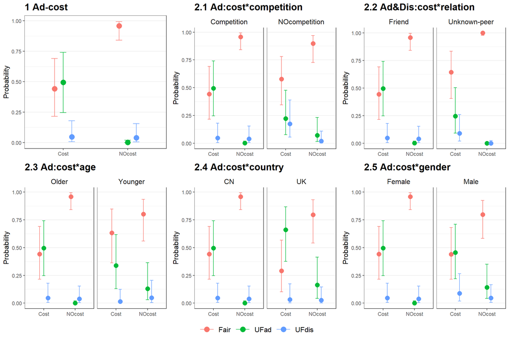

#### 4.2 interactions led by cost*competition

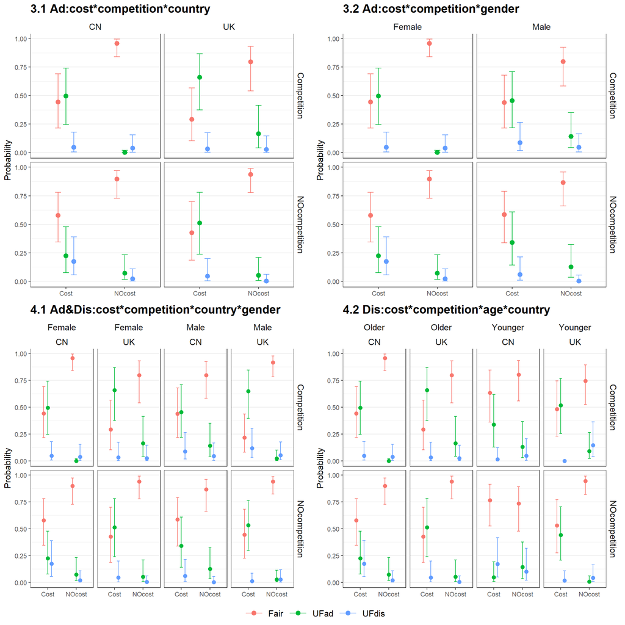

#### 4.3 interactions led by cost*relation

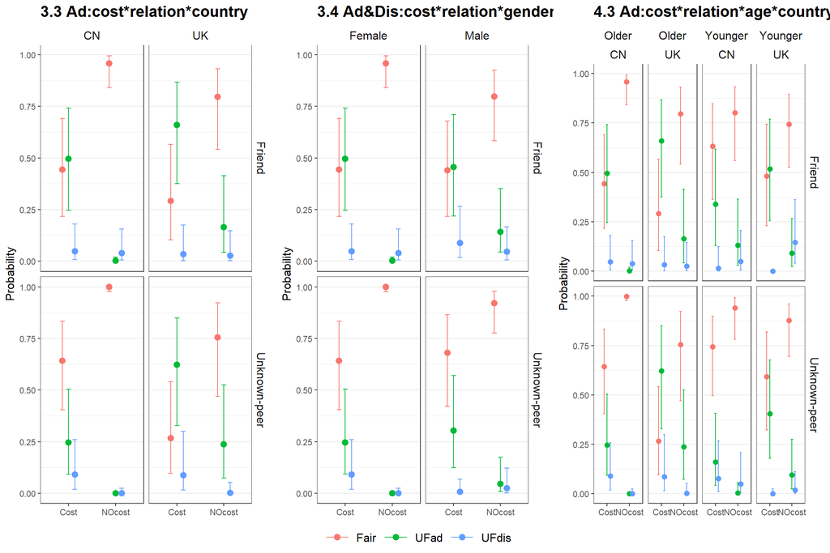

#### 4.4 interactions led by cost*contextural factors

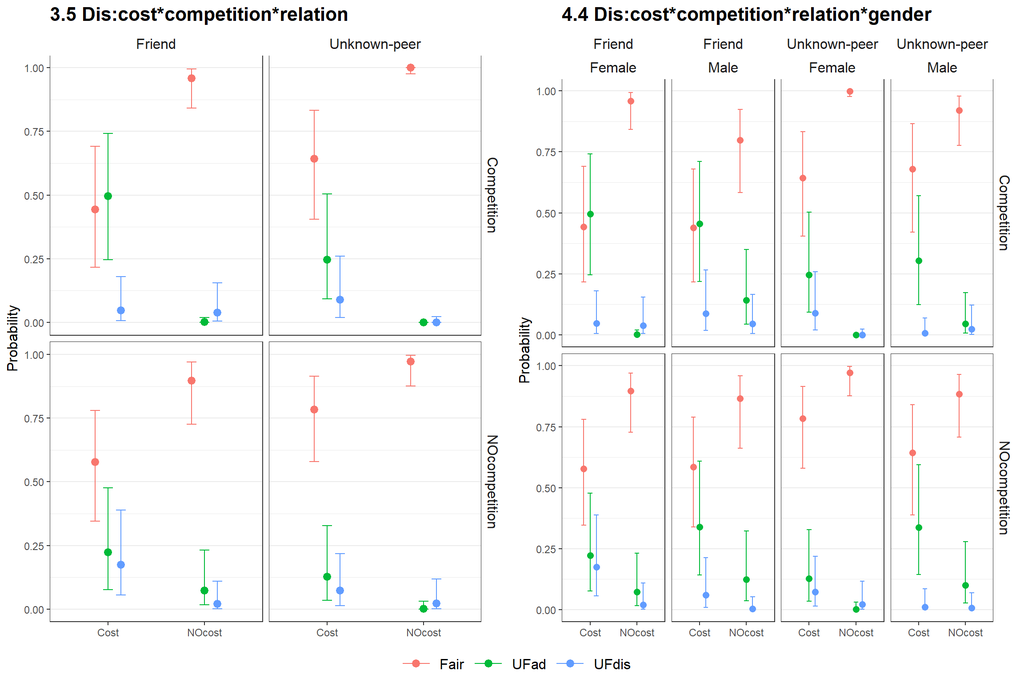

#### 4.5 interactions led by cost*structural factors

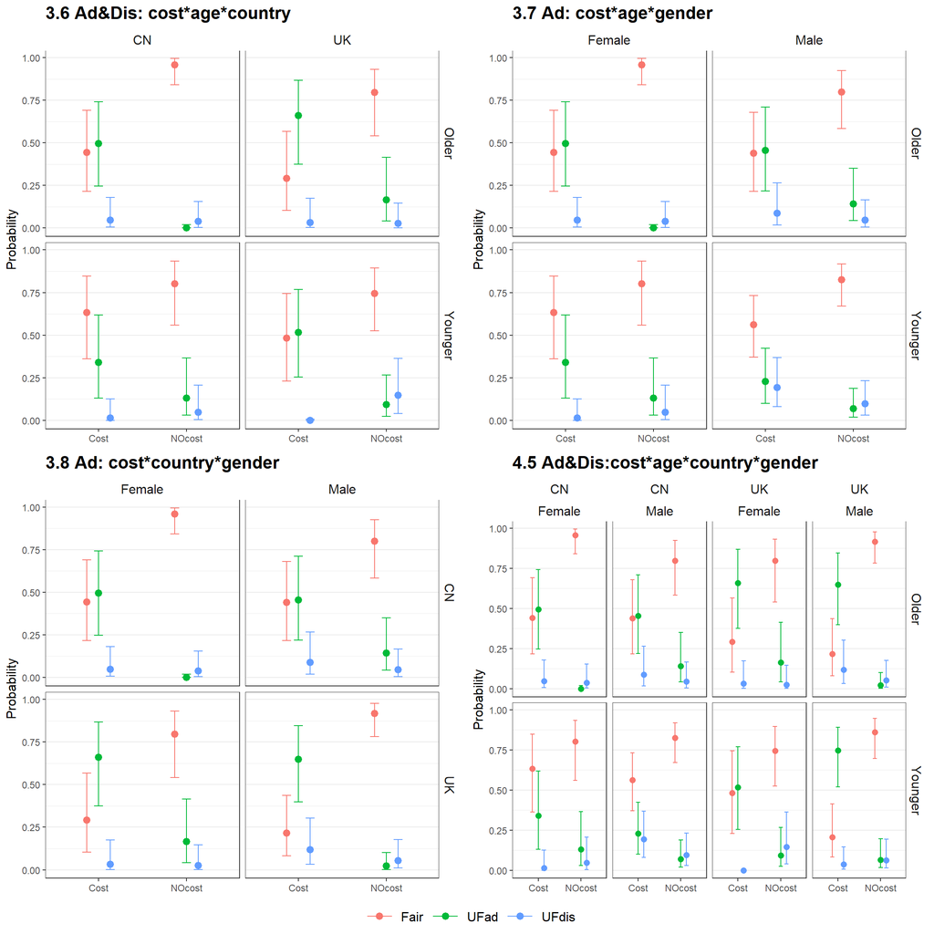